# Task 1: Data Preprocessing

# Task 2: Shallow neural Network

| Hyperparametes | values |
| --- | --- |
| # Layers | 1 |
| # Neuron per Layer | 32,64,128 |
| Activation | Linear |
| Batch size | 64 |
| Loss Function | Cross-entropy |
| Optimizer | AdamW |
| Learning Rate | 0.0005 |
| Epochs | 100 |
| Regularizations | None |

- Describe how you carried out the training process.
- How does the loss curve evolve during training on the training and validation set?
- How do you select the best model across epochs? Which model do you use for validation and test?
- What is the overall classification performance in the validation and test datasets and considering the different classes? Indicate the results.
- Why is the performance of the model so poor?

Change the model with the best performance (optimal number of neurons) by changing the activation function in ReLU and evaluate the effects.

```python
import torch.nn as nn
from sklearn.metrics import classification_report

# Define a simple linear model
class SimpleLinearModel(nn.Module):
    def __init__(self, input_size, output_size, hidden_size):
        super(SimpleLinearModel, self).__init__()
        self.hidden_layer = nn.Linear(input_size, hidden_size)
        self.output_layer = nn.Linear(hidden_size, output_size)

    def forward(self, x):
        x = self.hidden_layer(x)
        x = self.output_layer(x)
        return x

def prediction(model, data_loader, device=device):
    predictions, true_labels = [], []
    model.eval()
    for batch in data_loader:
        batch = tuple(t.to(device) for t in batch)
        inputs, labels = batch
        with torch.no_grad():
            outputs = model(inputs)
            _, preds = torch.max(outputs, 1)
            predictions.extend(preds.cpu().numpy())
            # If labels are one-hot, convert to class indices
            if labels.ndim > 1 and labels.shape[1] > 1:
                labels = torch.argmax(labels, dim=1)
            true_labels.extend(labels.cpu().numpy())
    # Convert to one-hot encoding
    num_classes = len(cateorical_labels)
    true_labels_onehot = np.eye(num_classes)[true_labels]
    predictions_onehot = np.eye(num_classes)[predictions]
    return predictions_onehot, true_labels_onehot
```

```python
# Initialize the model, loss function, and optimizer
from torch.utils.data import DataLoader, TensorDataset
import torch.optim as optim
import torch
import time

print(f"Train set size: {len(train_df)} ({len(train_df) / len(df) * 100:.2f}%)")
print(f"Validation set size: {len(validation_df)} ({len(validation_df) / len(df) * 100:.2f}%)")
print(f"Test set size: {len(test_df)} ({len(test_df) / len(df) * 100:.2f}%)")

neurons = 128

model = SimpleLinearModel(normalized_features.shape[1], len(cateorical_labels), neurons).to(device)
criterion = nn.CrossEntropyLoss()
optimizer = optim.AdamW(model.parameters(), lr=0.0005)
num_epochs = 100

# Create a mapping with model, criterion, and optimizer
linear_model_config = {
    "model": model,
    "criterion": criterion,
    "optimizer": optimizer,
    "epocs": num_epochs
}

# Convert DataFrames to PyTorch tensors and move them to the correct device
X_train_tensor = torch.tensor(train_df.drop(columns='Label').values, dtype=torch.float32).to(device)
Y_train_tensor = torch.tensor(train_df['Label'].values, dtype=torch.long).to(device)

X_val_tensor = torch.tensor(validation_df.drop(columns='Label').values, dtype=torch.float32).to(device)
Y_val_tensor = torch.tensor(validation_df['Label'].values, dtype=torch.long).to(device)

X_test_tensor = torch.tensor(test_df.drop(columns='Label').values, dtype=torch.float32).to(device)
Y_test_tensor = torch.tensor(test_df['Label'].values, dtype=torch.long).to(device)

# Create TensorDatasets
train_dataset = TensorDataset(X_train_tensor, Y_train_tensor)
val_dataset = TensorDataset(X_val_tensor, Y_val_tensor)
test_dataset = TensorDataset(X_test_tensor, Y_test_tensor)

# Create DataLoaders
train_loader = DataLoader(train_dataset, batch_size=64, shuffle=True, generator=torch.Generator().manual_seed(seed))
val_loader = DataLoader(val_dataset, batch_size=64, shuffle=False, generator=torch.Generator().manual_seed(seed))
test_loader = DataLoader(test_dataset, batch_size=64, shuffle=False, generator=torch.Generator().manual_seed(seed))
```

```
Train set size: 17630 (60.00%)
Validation set size: 5877 (20.00%)
Test set size: 5877 (20.00%)
```

```python
from tqdm import tqdm

def save_ckp(state, model_name):
    torch.save(state, str(model_name)+'.pt')

def train_model(model, train_loader, val_loader, optimizer, criterion, num_epochs, device=device, with_output=True, name="best_model"):
    train_losses = []
    val_losses = []
    start_time = time.time()
    valid_loss_min = np.inf # track change in validation loss


    model.to(device)
    pbar = tqdm(
        range(num_epochs),
        desc="Training Progress",
        disable=not with_output,
        unit="epoch",
        leave=True,
        position=0,
        ncols=100,
        bar_format='{l_bar}{bar}| [{rate_fmt}] {postfix}'
    )

    for epoch in pbar:
        train_loss = 0
        val_loss = 0

        # Training phase
        model.train()
        for X_batch, y_batch in train_loader:
            X_batch, y_batch = X_batch.to(device), y_batch.to(device)
            optimizer.zero_grad()
            y_pred = model(X_batch)
            loss = criterion(y_pred, y_batch)
            loss.backward()
            optimizer.step()
            train_loss += loss.item() * X_batch.size(0)
        train_loss /= len(train_loader.dataset)
        train_losses.append(train_loss)

        # Validation phase
        model.eval()
        with torch.no_grad():
            for X_val, y_val in val_loader:
                X_val, y_val = X_val.to(device), y_val.to(device)
                y_val_pred = model(X_val)
                val_loss += criterion(y_val_pred, y_val).item() * X_val.size(0)
            val_loss /= len(val_loader.dataset)
            val_losses.append(val_loss)

        # Save the model if validation loss has decreased
        is_best = val_loss < valid_loss_min
        if is_best:
            valid_loss_min = val_loss
            checkpoint = {
                'epoch': epoch + 1,
                'state_dict': model.state_dict(),
                'optimizer': optimizer.state_dict(),
                'valid_loss_min': valid_loss_min
            }
            save_ckp(checkpoint, name)
        pbar.set_postfix({"min validation loss": f"{valid_loss_min:.4f}", "best_epoch": checkpoint['epoch']})

    return train_losses, val_losses

train_losses, val_losses = train_model(model, train_loader, val_loader, optimizer, criterion, num_epochs, name="shallow_model")
```

```
Training Progress: 100%|███████████████| [ 4.52epoch/s] , min validation loss=0.3041, best_epoch=100
```

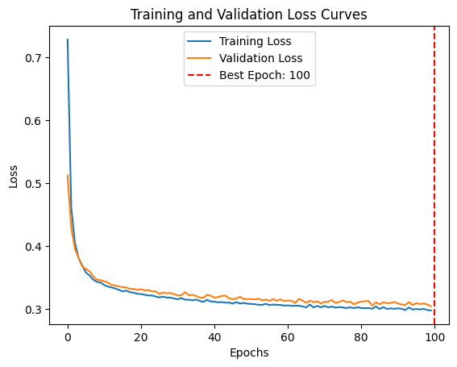

```python
sns.lineplot(x=range(num_epochs), y=train_losses, label='Training Loss')
sns.lineplot(x=range(num_epochs), y=val_losses, label='Validation Loss')
plt.xlabel('Epochs')
plt.ylabel('Loss')
plt.title('Training and Validation Loss Curves')
best_epoch = np.argmin(val_losses) + 1
plt.axvline(x=best_epoch, color='red', linestyle='--', label=f'Best Epoch: {best_epoch}')
plt.legend()

plt.savefig(f'{img_dir}curves_task_2.png')
plt.show()
```

| Neurons # | Min Validation Loss | Weighted Avg F1 | Macro Avg F1 |
| --- | --- | --- | --- |
| 32 | 0.3124 | 0.87 | 0.67 |
| 64 | 0.3070 | 0.87 | 0.68 |
| 128 | 0.3041 | 0.87 | 0.68 |

```python
from sklearn.metrics import classification_report, accuracy_score

# use the best model to predict
model.load_state_dict(torch.load("shallow_model.pt")['state_dict'])

# Get predictions and true labels for each set
pred_train, truelab_train = prediction(model, train_loader)
pred_val, truelab_val = prediction(model, val_loader)
pred_test, truelab_test = prediction(model, test_loader)

print("Train set")
print(classification_report(truelab_train, pred_train, target_names=label_names, zero_division=0))
print("Validation set")
print(classification_report(truelab_val, pred_val, target_names=label_names, zero_division=0))
print("Test set")
print(classification_report(truelab_test, pred_test, target_names=label_names, zero_division=0))

print(f"Train set accuracy: {accuracy_score(truelab_train.argmax(axis=1), pred_train.argmax(axis=1)):.4f}")
print(f"Validation set accuracy: {accuracy_score(truelab_val.argmax(axis=1), pred_val.argmax(axis=1)):.4f}")
print(f"Test set accuracy: {accuracy_score(truelab_test.argmax(axis=1), pred_test.argmax(axis=1)):.4f}")
```

```
Train set
              precision    recall  f1-score   support

      Benign       0.88      0.96      0.92     11544
 Brute Force       0.00      0.00      0.00       856
    DoS Hulk       0.99      0.86      0.92      2321
    PortScan       0.85      0.89      0.87      2909

   micro avg       0.89      0.89      0.89     17630
   macro avg       0.68      0.68      0.68     17630
weighted avg       0.85      0.89      0.87     17630
 samples avg       0.89      0.89      0.89     17630

Validation set
              precision    recall  f1-score   support

      Benign       0.88      0.96      0.92      3848
 Brute Force       0.00      0.00      0.00       285
    DoS Hulk       0.98      0.86      0.92       774
    PortScan       0.86      0.89      0.88       970

   micro avg       0.89      0.89      0.89      5877
   macro avg       0.68      0.68      0.68      5877
weighted avg       0.85      0.89      0.87      5877
 samples avg       0.89      0.89      0.89      5877

Test set
              precision    recall  f1-score   support

      Benign       0.89      0.96      0.92      3848
 Brute Force       0.00      0.00      0.00       286
    DoS Hulk       0.98      0.87      0.92       773
    PortScan       0.83      0.90      0.87       970

   micro avg       0.89      0.89      0.89      5877
   macro avg       0.68      0.68      0.68      5877
weighted avg       0.85      0.89      0.87      5877
 samples avg       0.89      0.89      0.89      5877

Train set accuracy: 0.8884
Validation set accuracy: 0.8903
Test set accuracy: 0.8892
```

```python
# Define a simple linear model
class SimpleReluModel(nn.Module):
    def __init__(self, input_size, output_size, hidden_size):
        super(SimpleReluModel, self).__init__()
        self.hidden_layer = nn.Sequential(
            nn.Linear(input_size, hidden_size),
            nn.ReLU()
        )
        self.output_layer = nn.Linear(hidden_size, output_size)

    def forward(self, x):
        x = self.hidden_layer(x)
        x = self.output_layer(x)
        return x


# Initialize the model, loss function, and optimizer
from torch.utils.data import DataLoader, TensorDataset
import torch.optim as optim
import torch

model = SimpleReluModel(normalized_features.shape[1], len(cateorical_labels), neurons).to(device)
criterion = nn.CrossEntropyLoss()
optimizer = optim.AdamW(model.parameters(), lr=0.0005)
num_epochs = 100

# Create a mapping with model, criterion, and optimizer
relu_model_config = {
    "model": model,
    "criterion": criterion,
    "optimizer": optimizer,
    "epochs": num_epochs
}
```

```python
train_losses, val_losses = train_model(model, train_loader, val_loader, optimizer, criterion, num_epochs, name="relu_model")
```

```
Training Progress: 100%|████████████████| [ 4.33epoch/s] , min validation loss=0.1302, best_epoch=99
```

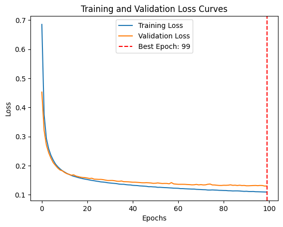

```python
sns.lineplot(x=range(num_epochs), y=train_losses, label='Training Loss')
sns.lineplot(x=range(num_epochs), y=val_losses, label='Validation Loss')
plt.xlabel('Epochs')
plt.ylabel('Loss')
plt.title('Training and Validation Loss Curves')
best_epoch = np.argmin(val_losses) + 1
plt.axvline(x=best_epoch, color='red', linestyle='--', label=f'Best Epoch: {best_epoch}')
plt.legend()
plt.savefig(f'{img_dir}curves_task_2_relu.png')
plt.show()
```

```python
model.load_state_dict(torch.load("relu_model.pt")['state_dict'])

pred_train, truelab_train = prediction(model, train_loader)
print("Train set")
print(classification_report(truelab_train, pred_train, zero_division=0, target_names=label_names))

pred_val, truelab_val = prediction(model, val_loader)
print("Validation set")
print(classification_report(truelab_val, pred_val, zero_division=0, target_names=label_names))

pred_test, truelab_test = prediction(model, test_loader)
print("Test set")
print(classification_report(truelab_test, pred_test, zero_division=0, target_names=label_names))

print(f"Train set accuracy: {accuracy_score(truelab_train.argmax(axis=1), pred_train.argmax(axis=1)):.4f}")
print(f"Validation set accuracy: {accuracy_score(truelab_val.argmax(axis=1), pred_val.argmax(axis=1)):.4f}")
print(f"Test set accuracy: {accuracy_score(truelab_test.argmax(axis=1), pred_test.argmax(axis=1)):.4f}")
```

```
Train set
              precision    recall  f1-score   support

      Benign       0.97      0.97      0.97     11544
 Brute Force       0.81      0.95      0.88       856
    DoS Hulk       0.98      0.94      0.96      2321
    PortScan       0.95      0.92      0.93      2909

   micro avg       0.96      0.96      0.96     17630
   macro avg       0.93      0.95      0.93     17630
weighted avg       0.96      0.96      0.96     17630
 samples avg       0.96      0.96      0.96     17630

Validation set
              precision    recall  f1-score   support

      Benign       0.97      0.97      0.97      3848
 Brute Force       0.81      0.96      0.88       285
    DoS Hulk       0.98      0.94      0.96       774
    PortScan       0.94      0.92      0.93       970

   micro avg       0.96      0.96      0.96      5877
   macro avg       0.93      0.95      0.93      5877
weighted avg       0.96      0.96      0.96      5877
 samples avg       0.96      0.96      0.96      5877

Test set
              precision    recall  f1-score   support

      Benign       0.97      0.96      0.97      3848
 Brute Force       0.81      0.91      0.86       286
    DoS Hulk       0.97      0.95      0.96       773
    PortScan       0.92      0.94      0.93       970

   micro avg       0.95      0.95      0.95      5877
   macro avg       0.92      0.94      0.93      5877
weighted avg       0.96      0.95      0.96      5877
 samples avg       0.95      0.95      0.95      5877

Train set accuracy: 0.9572
Validation set accuracy: 0.9559
Test set accuracy: 0.9549
```

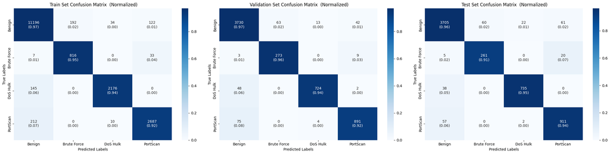

```python
from sklearn.metrics import confusion_matrix

def format_annot(matrix, normalized_matrix):
        return [[f"{int(matrix[i, j])}\n({normalized_matrix[i, j]:.2f})" for j in range(matrix.shape[1])] for i in range(matrix.shape[0])]

def plot_confusion_matrices(true_labels, predicted_labels, label_names, title_prefix="", title_postfix="", save_path=None):
    """
    Generalized function to compute and plot normalized confusion matrices.

    Parameters:
    - true_labels: List of true labels for datasets (e.g., [train_labels, val_labels, test_labels]).
    - predicted_labels: List of predicted labels for datasets (e.g., [train_preds, val_preds, test_preds]).
    - label_names: List of label names for the x and y axes of the confusion matrix.
    - title_prefix: Prefix for the titles of the confusion matrix plots.
    """


    fig, axes = plt.subplots(1, len(true_labels), figsize=(8 * len(true_labels), 6))

    sets = ["Train", "Validation", "Test"]
    for idx, (true, pred) in enumerate(zip(true_labels, predicted_labels)):
        cm = confusion_matrix(true.argmax(axis=1), pred.argmax(axis=1))
        cm_normalized = cm.astype('float') / cm.sum(axis=1)[:, np.newaxis]
        annot = format_annot(cm, cm_normalized)

        sns.heatmap(cm_normalized, annot=annot, fmt="", cmap="Blues",
                    xticklabels=label_names, yticklabels=label_names, ax=axes[idx])
        axes[idx].set_title(f"{title_prefix} {sets[idx]} Set Confusion Matrix {title_postfix} (Normalized)")
        axes[idx].set_xlabel("Predicted Labels")
        axes[idx].set_ylabel("True Labels")

    plt.tight_layout()
    if save_path:
        plt.savefig(save_path)
    plt.show()

# Example usage:
plot_confusion_matrices(
    true_labels=[truelab_train, truelab_val, truelab_test],
    predicted_labels=[pred_train, pred_val, pred_test],
    label_names=label_names,
    save_path=f'{img_dir}heat_task2_relu.png'
)
```

# Task 3: The impact of specific features

```python
bf_df = odf.copy()
bf_df.drop(columns=to_drop, inplace=True)  # Remove correlated features

print("Top 10 most common ports for bruteforce attacks:")
print(bf_df[bf_df['Label'] == 'Brute Force']['Destination Port'].value_counts().head(10).apply(lambda x: f"{x}"))
print("Distribution of port 80 per class of attack:")
print(bf_df[bf_df['Destination Port'] == 80]['Label'].value_counts().apply(lambda x: f"{x} ({x / len(bf_df[bf_df['Destination Port'] == 80]) * 100:.2f}%)"))
print()

encoder = LabelEncoder()
bf_df['Label'] = encoder.fit_transform(bf_df['Label'])

# Split the dataset into training, validation, and test sets (60%, 20%, 20%)
bf_train_df, bf_temp_df = train_test_split(bf_df, test_size=0.4, random_state=seed, stratify=bf_df['Label'])
bf_validation_df, bf_test_df = train_test_split(bf_temp_df, test_size=0.5, random_state=seed, stratify=bf_temp_df['Label'])

bruteforce_label = encoder.transform(['Brute Force'])[0]
# replace port 80 to 8080 for bruteforce attacks on the test set, as requested
bf_test_df.loc[(bf_test_df['Destination Port'] == 80) & (bf_test_df['Label'] == bruteforce_label), 'Destination Port'] = 8080

# count bruteforce attacks in the test set with destination port 80 and print it
if ((bf_test_df['Label'] == bruteforce_label) & (bf_test_df['Destination Port'] == 80)).sum() > 0:
    print(f'Something went wrong, there are still {((bf_test_df['Label'] == bruteforce_label) & (bf_test_df['Destination Port'] == 80)).sum()} brute force attacks in the test set with destination port 80.')
    from sys import exit
    exit(1)

# save labels
bf_train_label = bf_train_df['Label']
bf_validation_label = bf_validation_df['Label']
bf_test_label = bf_test_df['Label']

# drop labels
bf_train_df = bf_train_df.drop(columns=['Label'])
bf_validation_df = bf_validation_df.drop(columns=['Label'])
bf_test_df = bf_test_df.drop(columns=['Label'])

print(f"Number of unique ports in general: {bf_test_df['Destination Port'].nunique()}")
print("Top 10 most common ports:")
print(bf_test_df['Destination Port'].value_counts().head(10).apply(lambda x: f"{x}"))

# normalize the data
scaler = StandardScaler()
normalized_bf_train_df = scaler.fit_transform(bf_train_df)
normalized_bf_validation_df = scaler.transform(bf_validation_df)
normalized_bf_test_df = scaler.transform(bf_test_df)

# Modify dataframe with normalized features
bf_train_df = pd.DataFrame(normalized_bf_train_df, columns=bf_train_df.columns, index=bf_train_label.index)
bf_validation_df = pd.DataFrame(normalized_bf_validation_df, columns=bf_validation_df.columns, index=bf_validation_label.index)
bf_test_df = pd.DataFrame(normalized_bf_test_df, columns=bf_test_df.columns, index=bf_test_label.index)

# add labels back to the dataframes
bf_train_df = pd.concat([bf_train_df, bf_train_label], axis=1)
bf_validation_df = pd.concat([bf_validation_df, bf_validation_label], axis=1)
bf_test_df = pd.concat([bf_test_df, bf_test_label], axis=1)

# print("----------------------------------")
# bf_train_df.head()
# print("----------------------------------")
# print(bf_validation_df.head())
# print("----------------------------------")
# bf_test_df.head()
```

```
Top 10 most common ports for bruteforce attacks:
Destination Port
80    1427
Name: count, dtype: object
Distribution of port 80 per class of attack:
Label
DoS Hulk       3868 (52.55%)
Benign         2058 (27.96%)
Brute Force    1427 (19.39%)
PortScan           8 (0.11%)
Name: count, dtype: object

Number of unique ports in general: 1364
Top 10 most common ports:
Destination Port
53      1626
80      1178
443      937
8080     287
123       43
389       17
22        14
21        13
137        9
3268       7
Name: count, dtype: object
```

```
BF Test set
              precision    recall  f1-score   support

      Benign       0.91      0.96      0.94      3848
 Brute Force       0.00      0.00      0.00       286
    DoS Hulk       0.97      0.95      0.96       773
    PortScan       0.92      0.94      0.93       970

   micro avg       0.91      0.91      0.91      5877
   macro avg       0.70      0.71      0.71      5877
weighted avg       0.88      0.91      0.89      5877
 samples avg       0.91      0.91      0.91      5877

BF Test set accuracy: 0.9105
```

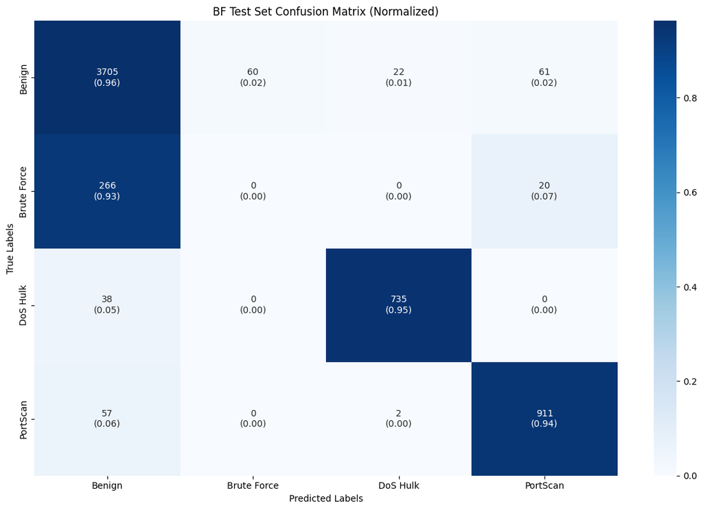

```python
# Prepare test tensors and DataLoader
X_bf_test = torch.tensor(bf_test_df.drop(columns=['Label']).values, dtype=torch.float32)
Y_bf_test = torch.tensor(bf_test_df['Label'].values, dtype=torch.long)
bf_test_dataset = TensorDataset(X_bf_test, Y_bf_test)
bf_test_loader = DataLoader(bf_test_dataset, batch_size=64, shuffle=False, generator=torch.Generator().manual_seed(seed))

# Load the best ReLU model
model.load_state_dict(torch.load("relu_model.pt")['state_dict'])

# Predict on Brute Force test set
bf_pred_test, bf_truelab_test = prediction(model, bf_test_loader)

print("BF Test set")
print(classification_report(bf_truelab_test, bf_pred_test, zero_division=0, target_names=label_names))

print(f"BF Test set accuracy: {accuracy_score(bf_truelab_test.argmax(axis=1), bf_pred_test.argmax(axis=1)):.4f}")

# Confusion matrix
bf_test_cm = confusion_matrix(bf_truelab_test.argmax(axis=1), bf_pred_test.argmax(axis=1))
# Avoid division by zero by setting invalid divisions to zero
row_sums = bf_test_cm.sum(axis=1, keepdims=True)
bf_test_cm_normalized = np.divide(
    bf_test_cm.astype('float'),
    row_sums,
    out=np.zeros_like(bf_test_cm, dtype=float),
    where=row_sums != 0
)
bf_test_annot = format_annot(bf_test_cm, bf_test_cm_normalized)

plt.figure(figsize=(12, 8))
sns.heatmap(bf_test_cm_normalized, annot=bf_test_annot, fmt="", cmap="Blues",
            xticklabels=label_names, yticklabels=label_names)
plt.title("BF Test Set Confusion Matrix (Normalized)")
plt.xlabel("Predicted Labels")
plt.ylabel("True Labels")
plt.tight_layout()
plt.savefig(f'{img_dir}heat_test_task3.png')
plt.show()
```

```python
## From now, work with a dataset without destination port label
f_df = bdf.copy() # final data frame

f_df = f_df.drop(columns=[*to_drop] + ['Destination Port'])
f_df = f_df.replace([np.inf, -np.inf], np.nan).dropna()
f_df = f_df[f_df.drop('Label', axis=1).ge(0).all(axis=1)]
f_df = f_df.drop_duplicates()

# Encode labels
encoder = LabelEncoder()
f_df['Label'] = encoder.fit_transform(f_df['Label'])
label_names = encoder.classes_.tolist()  # Get label names sorted by support size (descending)

f_train_df, f_temp_df = train_test_split(f_df, test_size=0.4, random_state=seed, stratify=f_df['Label'])
f_validation_df, f_test_df = train_test_split(f_temp_df, test_size=0.5, random_state=seed, stratify=f_temp_df['Label'])

# Save labels
f_train_label = f_train_df['Label']
f_validation_label = f_validation_df['Label']
f_test_label = f_test_df['Label']

# Drop labels from the dataframes
f_train_df = f_train_df.drop(columns=['Label'])
f_validation_df = f_validation_df.drop(columns=['Label'])
f_test_df = f_test_df.drop(columns=['Label'])

# Apply StandardScaler to the features
scaler = StandardScaler()
normalized_f_train_df = scaler.fit_transform(f_train_df)
normalized_f_validation_df = scaler.transform(f_validation_df)
normalized_f_test_df = scaler.transform(f_test_df)

# Modify dataframes with normalized features
f_train_df = pd.DataFrame(normalized_f_train_df, columns=f_train_df.columns, index=f_train_label.index)
f_validation_df = pd.DataFrame(normalized_f_validation_df, columns=f_validation_df.columns, index=f_validation_label.index)
f_test_df = pd.DataFrame(normalized_f_test_df, columns=f_test_df.columns, index=f_test_label.index)

# Add labels back to the dataframes
f_train_df = pd.concat([f_train_df, f_train_label], axis=1)
f_validation_df = pd.concat([f_validation_df, f_validation_label], axis=1)
f_test_df = pd.concat([f_test_df, f_test_label], axis=1)

print(f"f_train_df: {f_train_df.shape}, f_validation_df: {f_validation_df.shape}, f_test_df: {f_test_df.shape}")
```

```
f_train_df: (13480, 14), f_validation_df: (4494, 14), f_test_df: (4494, 14)
```

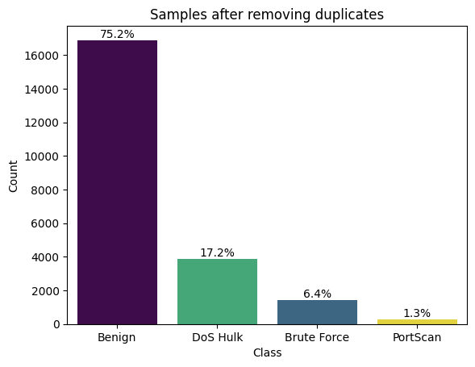

```
Number of PortScan samples in df:  4849
Number of PortScan samples in f_df:  285
Percentage drop of PortScan samples:  94.12%
```

```python
# Get counts and percentages
counts = f_df['Label'].value_counts()
percentages = counts / counts.sum() * 100
counts_sorted = counts.sort_values(ascending=False).values
percentages_sorted = percentages.sort_values(ascending=False).values

# Create the bar plot
ax = sns.barplot(
    x=counts.index,
    y=counts_sorted,
    order=counts.index,
    palette='viridis',
    hue=counts.index,
    legend=False
)
plt.title("Samples after removing duplicates")
locs, labels = plt.xticks()
plt.setp(labels, rotation=0, ha='center')
plt.xticks(labels=encoder.inverse_transform(counts.index), rotation=0, ticks=locs)

# Add percentage labels on top of bars
for i, p in enumerate(ax.patches):
    height = p.get_height()
    percent = f'{100 * height / len(f_df):.1f}%'
    plt.gca().text(
        p.get_x() + p.get_width() / 2,
        height,
        percent,
        ha='center',
        va='bottom',
        fontsize=10,
        color='black'
    )

plt.xlabel("Class")
plt.ylabel("Count")
plt.savefig(f'{img_dir}class_distribution_no_port.png')
plt.show()

# Print number of PortScan samples in df and f_df
print("Number of PortScan samples in df: ", len(df['Label'][df['Label'] == encoder.transform(['PortScan'])[0]]))
print("Number of PortScan samples in f_df: ", len(f_df[f_df['Label'] == encoder.transform(['PortScan'])[0]]))
print("Percentage drop of PortScan samples: ",
      f"{(len(df['Label'][df['Label'] == encoder.transform(['PortScan'])[0]]) - len(f_df[f_df['Label'] == encoder.transform(['PortScan'])[0]])) / len(df['Label'][df['Label'] == encoder.transform(['PortScan'])[0]]) * 100:.2f}%")
```

```python
# Convert DataFrames to PyTorch tensors and move them to the correct device
X_f_train_tensor = torch.tensor(f_train_df.drop(columns=['Label']).values, dtype=torch.float32).to(device)
Y_f_train_tensor = torch.tensor(f_train_df['Label'].values, dtype=torch.long).to(device)

X_f_val_tensor = torch.tensor(f_validation_df.drop(columns=['Label']).values, dtype=torch.float32).to(device)
Y_f_val_tensor = torch.tensor(f_validation_df['Label'].values, dtype=torch.long).to(device)

X_f_test_tensor = torch.tensor(f_test_df.drop(columns=['Label']).values, dtype=torch.float32).to(device)
Y_f_test_tensor = torch.tensor(f_test_df['Label'].values, dtype=torch.long).to(device)

# Create TensorDatasets
f_train_dataset = TensorDataset(X_f_train_tensor, Y_f_train_tensor)
f_val_dataset = TensorDataset(X_f_val_tensor, Y_f_val_tensor)
f_test_dataset = TensorDataset(X_f_test_tensor, Y_f_test_tensor)

# Create DataLoaders
f_train_loader = DataLoader(f_train_dataset, batch_size=64, shuffle=True, generator=torch.Generator().manual_seed(seed))
f_val_loader = DataLoader(f_val_dataset, batch_size=64, shuffle=False, generator=torch.Generator().manual_seed(seed))
f_test_loader = DataLoader(f_test_dataset, batch_size=64, shuffle=False, generator=torch.Generator().manual_seed(seed))
```

```
Training Progress: 100%|████████████████| [ 5.65epoch/s] , min validation loss=0.1117, best_epoch=94
```

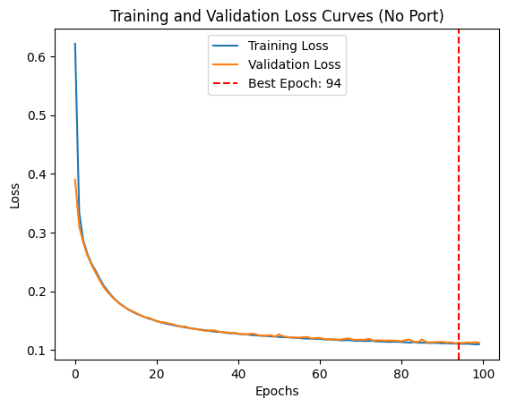

```python
# Retrain the model with the best architecture
f_model = SimpleReluModel(normalized_f_train_df.shape[1], len(label_names), 128).to(device)
f_criterion = nn.CrossEntropyLoss()
f_optimizer = optim.AdamW(f_model.parameters(), lr=0.0005)
f_num_epochs = 100

f_relu_model_config = {
    'model': f_model,
    'criterion': f_criterion,
    'optimizer': f_optimizer,
    'num_epochs': f_num_epochs
}

# Train the model
f_train_losses, f_val_losses = train_model(f_model, f_train_loader, f_val_loader, f_optimizer, f_criterion, f_num_epochs, name="best_relu_model")
sns.lineplot(x=range(f_num_epochs), y=f_train_losses, label='Training Loss')
sns.lineplot(x=range(f_num_epochs), y=f_val_losses, label='Validation Loss')
plt.xlabel('Epochs')
plt.ylabel('Loss')
plt.title('Training and Validation Loss Curves (No Port)')
best_epoch = np.argmin(f_val_losses) + 1
plt.axvline(x=best_epoch, color='red', linestyle='--', label=f'Best Epoch: {best_epoch}')
plt.legend()
plt.savefig(f'{img_dir}curves_task_3_no_weight.png')
plt.show()
# Epoch 100/100, Training Loss: 0.1088, Validation Loss: 0.1229, Time: 24.65s
```

```python
f_model.load_state_dict(torch.load("best_relu_model.pt")['state_dict'])

f_pred_train, f_truelab_train = prediction(f_model, f_train_loader)
print("Train set")
print(classification_report(f_truelab_train, f_pred_train, target_names=label_names, zero_division=0))

f_pred_val, f_truelab_val = prediction(f_model, f_val_loader)
print("Validation set")
print(classification_report(f_truelab_val, f_pred_val, target_names=label_names, zero_division=0))

f_pred_test, f_truelab_test = prediction(f_model, f_test_loader)
print("Test set")
print(classification_report(f_truelab_test, f_pred_test, target_names=label_names, zero_division=0))

print(f"Train set accuracy: {accuracy_score(f_truelab_train, f_pred_train):.4f}")
print(f"Validation set accuracy: {accuracy_score(f_truelab_val, f_pred_val):.4f}")
print(f"Test set accuracy: {accuracy_score(f_truelab_test, f_pred_test):.4f}")
```

```
Train set
              precision    recall  f1-score   support

      Benign       0.97      0.98      0.97     10132
 Brute Force       0.81      0.94      0.87       856
    DoS Hulk       1.00      0.91      0.95      2321
    PortScan       0.50      0.47      0.48       171

   micro avg       0.95      0.95      0.95     13480
   macro avg       0.82      0.82      0.82     13480
weighted avg       0.96      0.95      0.96     13480
 samples avg       0.95      0.95      0.95     13480

Validation set
              precision    recall  f1-score   support

      Benign       0.96      0.97      0.97      3378
 Brute Force       0.80      0.95      0.87       285
    DoS Hulk       0.99      0.89      0.94       774
    PortScan       0.49      0.35      0.41        57

   micro avg       0.95      0.95      0.95      4494
   macro avg       0.81      0.79      0.80      4494
weighted avg       0.95      0.95      0.95      4494
 samples avg       0.95      0.95      0.95      4494

Test set
              precision    recall  f1-score   support

      Benign       0.96      0.97      0.97      3378
 Brute Force       0.81      0.95      0.87       286
    DoS Hulk       0.99      0.89      0.94       773
    PortScan       0.45      0.35      0.40        57

   micro avg       0.95      0.95      0.95      4494
   macro avg       0.80      0.79      0.79      4494
weighted avg       0.95      0.95      0.95      4494
 samples avg       0.95      0.95      0.95      4494

Train set accuracy: 0.9550
Validation set accuracy: 0.9508
Test set accuracy: 0.9506
```

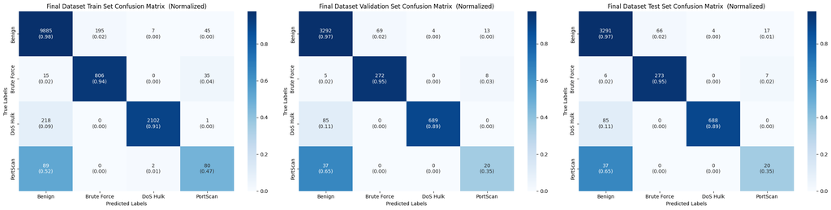

```python
plot_confusion_matrices(
    true_labels=[f_truelab_train, f_truelab_val, f_truelab_test],
    predicted_labels=[f_pred_train, f_pred_val, f_pred_test],
    label_names=label_names,
    title_prefix="Final Dataset",
    save_path=f'{img_dir}heat_final_no_weight_task3.png'
)
```

```
Class weights: Benign: 0.33, Brute Force: 3.94, DoS Hulk: 1.45, PortScan: 19.71,
```

```
Training Progress: 100%|████████████████| [ 5.55epoch/s] , min validation loss=0.1734, best_epoch=98
```

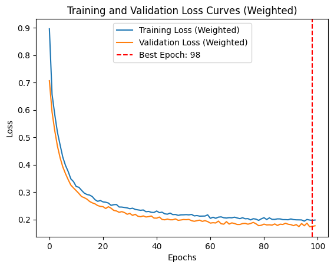

```python
from sklearn.utils.class_weight import compute_class_weight

# Convert one-hot labels to class indices
class_weights = compute_class_weight(class_weight="balanced", classes=np.arange(len(label_names)), y=f_train_df['Label'])
print('Class weights:', end=' ')
for name, weight in zip(label_names, class_weights):
    print(f"{name}: {weight:.2f}", end=', ')
class_weights_tensor = torch.tensor(class_weights, dtype=torch.float32, device=device)

# Update the criterion to use the computed class weights
model = SimpleReluModel(normalized_f_train_df.shape[1], len(label_names), 128).to(device)
fw_criterion = nn.CrossEntropyLoss(weight=class_weights_tensor).to(device)
fw_optimizer = optim.AdamW(model.parameters(), lr=0.0005)

f_train_losses_weighted, f_val_losses_weighted = train_model(
    model,
    f_train_loader, f_val_loader,
    fw_optimizer, fw_criterion,
    f_relu_model_config['num_epochs'], with_output=True,
    name="best_relu_model_weighted"
)

# Plot the training and validation loss curves
sns.lineplot(x=range(num_epochs), y=f_train_losses_weighted, label='Training Loss (Weighted)')
sns.lineplot(x=range(num_epochs), y=f_val_losses_weighted, label='Validation Loss (Weighted)')
plt.xlabel('Epochs')
plt.ylabel('Loss')
plt.title('Training and Validation Loss Curves (Weighted)')
best_epoch = np.argmin(f_val_losses_weighted) + 1
plt.axvline(x=best_epoch, color='red', linestyle='--', label=f'Best Epoch: {best_epoch}')
plt.legend()
plt.savefig(f'{img_dir}curves_task_3_weighted.png')
plt.show()
```

```python
f_model.load_state_dict(torch.load("best_relu_model_weighted.pt")['state_dict'])

f_pred_train, f_truelab_train = prediction(f_model, f_train_loader)
print("Train set")
print(classification_report(f_truelab_train, f_pred_train, target_names=label_names, zero_division=0))

f_pred_val, f_truelab_val = prediction(f_model, f_val_loader)
print("Validation set")
print(classification_report(f_truelab_val, f_pred_val, target_names=label_names, zero_division=0))

f_pred_test, f_truelab_test = prediction(f_model, f_test_loader)
print("Test set")
print(classification_report(f_truelab_test, f_pred_test, target_names=label_names, zero_division=0))

print(f"Train set accuracy with class weights: {accuracy_score(f_truelab_train.argmax(axis=1), f_pred_train.argmax(axis=1)):.4f}")
print(f"Validation set accuracy with class weights: {accuracy_score(f_truelab_val.argmax(axis=1), f_pred_val.argmax(axis=1)):.4f}")
print(f"Test set accuracy with class weights: {accuracy_score(f_truelab_test.argmax(axis=1), f_pred_test.argmax(axis=1)):.4f}")
```

```
Train set
              precision    recall  f1-score   support

      Benign       0.99      0.93      0.96     10132
 Brute Force       0.78      0.94      0.85       856
    DoS Hulk       0.93      0.94      0.93      2321
    PortScan       0.29      0.95      0.45       171

   micro avg       0.93      0.93      0.93     13480
   macro avg       0.75      0.94      0.80     13480
weighted avg       0.96      0.93      0.94     13480
 samples avg       0.93      0.93      0.93     13480

Validation set
              precision    recall  f1-score   support

      Benign       0.99      0.93      0.96      3378
 Brute Force       0.77      0.96      0.85       285
    DoS Hulk       0.94      0.93      0.93       774
    PortScan       0.30      0.96      0.45        57

   micro avg       0.93      0.93      0.93      4494
   macro avg       0.75      0.95      0.80      4494
weighted avg       0.96      0.93      0.94      4494
 samples avg       0.93      0.93      0.93      4494

Test set
              precision    recall  f1-score   support

      Benign       0.99      0.92      0.95      3378
 Brute Force       0.78      0.96      0.86       286
    DoS Hulk       0.92      0.93      0.93       773
    PortScan       0.27      0.96      0.42        57

   micro avg       0.93      0.93      0.93      4494
   macro avg       0.74      0.94      0.79      4494
weighted avg       0.95      0.93      0.94      4494
 samples avg       0.93      0.93      0.93      4494

Train set accuracy with class weights: 0.9329
Validation set accuracy with class weights: 0.9330
Test set accuracy with class weights: 0.9266
```

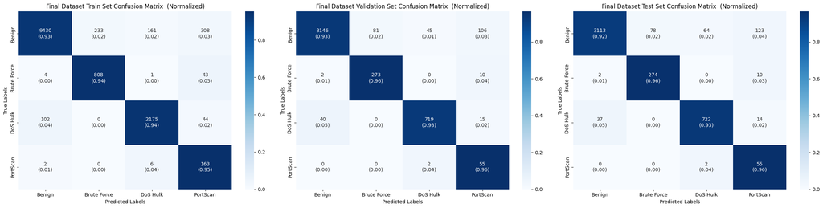

```python
# plot confusion matrix
plot_confusion_matrices(
    true_labels=[f_truelab_train, f_truelab_val, f_truelab_test],
    predicted_labels=[f_pred_train, f_pred_val, f_pred_test],
    label_names=label_names,
    title_prefix="Final Dataset",
    save_path=f'{img_dir}heat_final_task3_weighted.png'
)
```

# Task 4: Deep Neural Network

| Hyperparameter | Value |
| --- | --- |
| Layers | 2 to 5 |
| Neurons per Layer | {2, 4, 8, 16, 32} (layers can have different sizes) |
| Activation | ReLU |
| Weight Initialization | Default |
| Batch Size | 64 |
| Loss Function | Cross-Entropy |
| Optimizer | AdamW |
| Learning Rate | 0.0005 |
| Epochs & Early Stopping | 50 or shorter based on the designed criteria |
| Regularization | None |

```python
# Define the neural network model
class DeepLearningModel(nn.Module):
    def __init__(self, input_size: int, output_size: int, num_layers: int=2, neurons_per_layer: tuple=None, activation='relu') -> None:
        super(DeepLearningModel, self).__init__()
        assert num_layers == len(neurons_per_layer), f"Number of layers must match the length of neurons_per_layer list"
        assert 2 <= num_layers <= 6, "The model must have between 2 and 6 layers"

        layers = []
        prev_size = input_size

        for i in range(num_layers):
            layers.append(nn.Linear(prev_size, neurons_per_layer[i]))
            if activation == 'relu':
                layers.append(nn.ReLU())
            elif activation == 'sigmoid':
                layers.append(nn.Sigmoid())
            elif activation == 'linear':
                pass
            else:
                raise ValueError(f"Unsupported activation function: {activation}")
            prev_size = neurons_per_layer[i]

        # Output layer
        layers.append(nn.Linear(prev_size, output_size))

        self.model = nn.Sequential(*layers)

    def forward(self, x):
        return self.model(x)
```

```python
from sklearn.model_selection import GridSearchCV
from sklearn.base import BaseEstimator, ClassifierMixin
from sklearn.metrics import make_scorer, f1_score, accuracy_score
import torch.nn as nn
import torch.optim as optim
import torch
import numpy as np
import itertools
from torch.utils.data import TensorDataset, DataLoader
import gc


class PyTorchClassifier(BaseEstimator, ClassifierMixin):
    def __init__(self, input_size: int, output_size: int, num_layers: int=2, neurons_per_layer: tuple=None, learning_rate=0.0005, epochs=50, batch_size=64, activation='relu', optimizer='adamw', momentum=0.9):
        self.input_size = input_size
        self.output_size = output_size
        self.num_layers = num_layers
        self.neurons_per_layer = neurons_per_layer
        self.learning_rate = learning_rate
        self.epochs = epochs
        self.batch_size = batch_size
        self.activation = activation
        self.optimizer = optimizer
        self.momentum = momentum
        self.model = None
        self.device = torch.device("cuda" if torch.cuda.is_available() else "cpu")

    def _cleanup(self):
        """Helper method to clean up GPU memory"""
        if hasattr(self, 'model') and self.model is not None:
            self.model.cpu()
            del self.model
            self.model = None
        if torch.cuda.is_available():
            torch.cuda.empty_cache()
        gc.collect()

    def _get_optimizer(self):
        if self.optimizer == 'adamw':
            return optim.AdamW(self.model.parameters(), lr=self.learning_rate)
        elif self.optimizer == 'sgd':
            return optim.SGD(self.model.parameters(), lr=self.learning_rate)
        elif self.optimizer == 'momentum_sgd':
            return optim.SGD(self.model.parameters(), lr=self.learning_rate, momentum=self.momentum)
        else: # default to adam
            return optim.Adam(self.model.parameters(), lr=self.learning_rate)

    def fit(self, X: np.ndarray, y: np.ndarray):
        self._cleanup()

        # Convert NumPy arrays to tensors and move to the correct device
        X_tensor = torch.tensor(X, dtype=torch.float32).to(self.device)
        # Assuming y is one-hot encoded, get class indices
        y_tensor = torch.tensor(y, dtype=torch.long).to(self.device)

        dataset = TensorDataset(X_tensor, y_tensor)
        train_loader = DataLoader(dataset, batch_size=self.batch_size, shuffle=True, generator=torch.Generator().manual_seed(42))

        self.model = DeepLearningModel(
            self.input_size,
            self.output_size,
            self.num_layers,
            self.neurons_per_layer
        ).to(self.device)

        # Ensure class_weights_tensor is on the correct device
        criterion = nn.CrossEntropyLoss()
        optimizer = self._get_optimizer()

        self.model.train()
        for epoch in range(self.epochs):
            for X_batch, y_batch in train_loader:
                optimizer.zero_grad()
                outputs = self.model(X_batch)
                loss = criterion(outputs, y_batch)
                loss.backward()
                optimizer.step()

        return self

    def predict(self, X: np.ndarray):
        if self.model is None:
            raise RuntimeError("You must train the model before making predictions.")
        self.model.eval()
        X_tensor = torch.tensor(X, dtype=torch.float32).to(self.device)
        with torch.no_grad():
            outputs = self.model(X_tensor)
            _, predicted = torch.max(outputs, 1)
        return predicted.cpu().numpy()
```

```python
import itertools

# Define the parameter grid
epocs = 50
learining_rate = 0.0005
batch_size = 64
param_grid =  [
    {
        'num_layers': [i],
        'neurons_per_layer': list(itertools.product([2, 4, 8, 16, 32], repeat=i)),
        'learning_rate': [learining_rate],
        'epochs': [epocs],
        'batch_size': [batch_size]
    }  for i in range (2,6)
]

# Fuse together f_train_df and f_validation_df to prepare for manual fold
f_combined_df = pd.concat([f_train_df, f_validation_df], ignore_index=True)

# Create a mask of -1 and 0 for manual fold
mask = [-1 if i < len(f_train_df) else 0 for i in range(len(f_combined_df))]
input_size = f_combined_df.drop(columns=['Label']).shape[1]
output_size = len(label_names)

X_combined = f_combined_df.drop(columns=['Label']).values
y_combined = f_combined_df['Label'].values

cores = -1 # -1 for all available ones, Use small positive number to save up space

best_model = None
```

```python
%%script false --no-raise-error
from sklearn.model_selection import PredefinedSplit
cv = PredefinedSplit(test_fold=mask)

# Wrap the PyTorch model
classifier = PyTorchClassifier(input_size=input_size, output_size=output_size)

# Define the scoring metric
scorer = make_scorer(f1_score, average='weighted', zero_division=0)

# Perform GridSearchCV
grid_search = GridSearchCV(estimator=classifier, param_grid=param_grid, scoring=scorer, cv=cv, n_jobs=cores, verbose=3, error_score='raise', return_train_score=False)
grid_search.fit(X_combined, y_combined)

# Print the best parameters and score
print("Best Parameters:", grid_search.best_params_)
print("Best Score:", grid_search.best_score_)

# Save each value to out.txt, i mean for each parameter
with open('out.txt', 'w') as f:
    for key, value in grid_search.best_params_.items():
        f.write(f"{key}: {value}\n")
    f.write(f"Best Score: {grid_search.best_score_}\n")
    f.write(f"Best Parameters: {grid_search.best_params_}\n")
    f.write(f"Best Score: {grid_search.best_score_}\n")
#
# Evaluate the best model on the test set
best_model = grid_search.best_estimator_
test_predictions = best_model.predict(f_test_df.drop(columns=cateorical_labels).values)
print("Test Set Accuracy:", accuracy_score(f_test_df[cateorical_labels].values, test_predictions))
print("F1 Score:", f1_score(f_test_df[cateorical_labels].values, test_predictions, average='weighted', zero_division=0))
```

```python
# if out.txt already exists, append the results
from os import path
if path.exists('out.txt'):

    import re

    # Open the file and read until the first empty line
    with open('out.txt', 'r') as file:
        lines = []
        for line in file:
            if line.strip() == "":
                break
            lines.append(line.strip())
        lines = lines[1:]

    data = []
    for line in lines:
        match = re.search(r".*neurons_per_layer=\((.*?)\).*?score=([\d.]+)", line)
        if match:
            neurons_per_layer = tuple(map(int, match.group(1).split(',')))
            score = float(match.group(2))
            data.append({"neurons_per_layer": neurons_per_layer, "score": score})
    gs_df = pd.DataFrame(data).groupby("neurons_per_layer", as_index=False)["score"].mean()
    print("Top 10")
    print(gs_df.nlargest(10, 'score'))

    top10 = gs_df.nlargest(10, 'score')['neurons_per_layer'].values
else:
    top10 = [
        (32, 32, 32, 32, 4),
        (32, 32, 4, 32, 32),
        (32, 32, 32, 32, 8),
        (8, 16, 16, 32, 16),
        (16, 4, 32, 8, 16),
        (32, 8, 8, 2, 32),
        (32, 32, 2, 8, 32),
        (32, 32, 4, 16, 16),
        (32, 16, 16, 4, 32),
        (32, 32, 32, 32, 16)
    ]
```

```python
skip_top_10_grid_search = True  # Set to True to skip the top 10 grid search, it takes about 15 minutes to run
if not skip_top_10_grid_search:

    from sklearn.model_selection import StratifiedKFold

    neurons_per_layer = top10 if type(top10) is list else gs_df.nlargest(10, 'score')['neurons_per_layer'].values.tolist()
    param_grid = {
        'neurons_per_layer': neurons_per_layer,
        'num_layers': [len(config) for config in neurons_per_layer],
        'learning_rate': [0.0005],
        'batch_size': [64],
        'epochs': [50],
    }

    # Convert one-hot encoded labels to class indices for stratification
    y_combined_indices = np.argmax(y_combined, axis=1)
    cv = StratifiedKFold(n_splits=5, shuffle=True, random_state=seed).split(X_combined, y_combined_indices)

    X_combined = X_combined.astype(np.float32)
    y_combined = y_combined.astype(np.int64)

    classifier = PyTorchClassifier(input_size=input_size, output_size=output_size)
    scorer = make_scorer(f1_score, average='weighted', zero_division=0)

    grid_search = GridSearchCV(
        estimator=classifier,
        param_grid=param_grid,
        scoring=scorer,
        cv=cv,
        n_jobs=cores
    )
    grid_search.fit(X_combined, y_combined)

    print("Best Parameters:", grid_search.best_params_)
    print("Best Score:", grid_search.best_score_)

    best_model = grid_search.best_estimator_
    test_predictions = best_model.predict(f_test_df.drop(columns=label_names).values)
    print("Test Set Accuracy:", accuracy_score(np.argmax(f_test_df[label_names].values, axis=1), test_predictions.argmax(axis=1)))
    print("F1 Score:", f1_score(np.argmax(f_test_df[label_names].values, axis=1), test_predictions.argmax(axis=1), average='weighted', zero_division=0))
else:
    top10 = [(32, 16, 32, 32, 32), *top10]  # hardcoded best configuration
```

```
Training Progress: 100%|████████████████| [ 3.88epoch/s] , min validation loss=0.0967, best_epoch=49
```

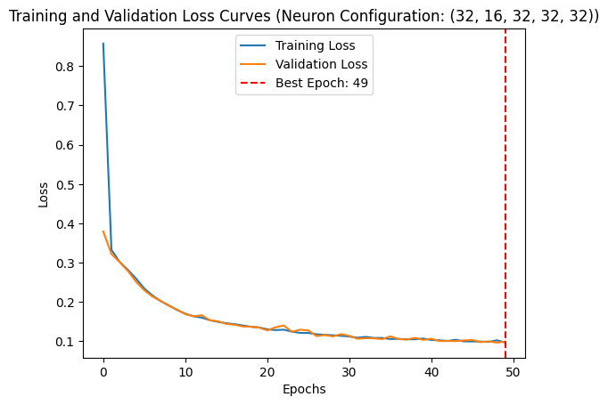

```
Train set
              precision    recall  f1-score   support

      Benign       0.97      0.99      0.98     10132
 Brute Force       0.93      0.94      0.94       856
    DoS Hulk       0.99      0.92      0.95      2321
    PortScan       0.57      0.70      0.62       171

   micro avg       0.97      0.97      0.97     13480
   macro avg       0.86      0.89      0.87     13480
weighted avg       0.97      0.97      0.97     13480
 samples avg       0.97      0.97      0.97     13480

Validation set
              precision    recall  f1-score   support

      Benign       0.97      0.98      0.98      3378
 Brute Force       0.93      0.96      0.95       285
    DoS Hulk       0.98      0.90      0.94       774
    PortScan       0.54      0.65      0.59        57

   micro avg       0.96      0.96      0.96      4494
   macro avg       0.86      0.87      0.86      4494
weighted avg       0.97      0.96      0.96      4494
 samples avg       0.96      0.96      0.96      4494

validation accuracy: 0.9644
Test set
              precision    recall  f1-score   support

      Benign       0.97      0.98      0.98      3378
 Brute Force       0.92      0.96      0.94       286
    DoS Hulk       0.98      0.90      0.94       773
    PortScan       0.55      0.60      0.57        57

   micro avg       0.96      0.96      0.96      4494
   macro avg       0.85      0.86      0.86      4494
weighted avg       0.96      0.96      0.96      4494
 samples avg       0.96      0.96      0.96      4494

Test set accuracy: 0.9611
```

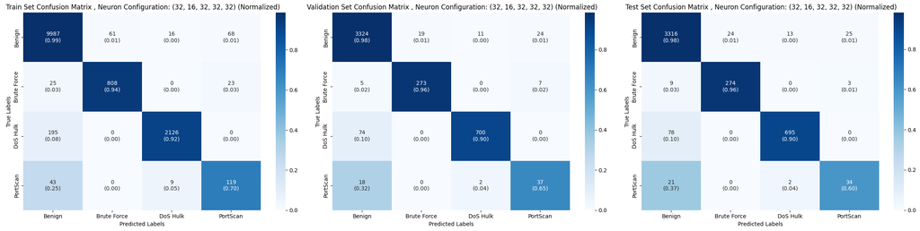

```
Test Set Accuracy: 0.9610591900311527
```

```python
# Define the model with the specified parameters
num_layers = best_model.num_layers \
    if best_model is not None and hasattr(best_model, 'num_layers') and best_model.num_layers is not None \
    else len(top10[0])  # Use the length of the first configuration if not specified
neurons_per_layer = best_model.neurons_per_layer \
    if best_model is not None and hasattr(best_model, 'neurons_per_layer') and best_model.neurons_per_layer is not None \
    else top10[0]  # Use the first configuration if not specified

manual_model = DeepLearningModel(
    input_size=input_size,
    output_size=output_size,
    num_layers=num_layers,
    neurons_per_layer=neurons_per_layer,
    activation='relu'
)

# Define the loss function and optimizer
manual_criterion = nn.CrossEntropyLoss()
manual_optimizer = optim.AdamW(manual_model.parameters(), lr=learining_rate)

# Train the model
manual_train_losses, manual_val_losses = train_model(
    manual_model,
    f_train_loader,
    f_val_loader,
    manual_optimizer,
    manual_criterion,
    num_epochs=50,
    with_output=True,
    name="manual_model"
)

# Plot the training and validation loss curves
sns.lineplot(x=range(50), y=manual_train_losses, label='Training Loss')
sns.lineplot(x=range(50), y=manual_val_losses, label='Validation Loss')
plt.xlabel('Epochs')
plt.ylabel('Loss')
plt.title('Training and Validation Loss Curves (Neuron Configuration: ' + str(neurons_per_layer) + ')')
best_epoch = np.argmin(manual_val_losses) + 1
plt.axvline(x=best_epoch, color='red', linestyle='--', label=f'Best Epoch: {best_epoch}')  # +1 because epochs are 0-indexed
plt.legend()
plt.savefig(f'{img_dir}curves_task_4_best_model.png')
plt.show()

manual_model.load_state_dict(torch.load("manual_model.pt")['state_dict'])

# Evaluate the model on the test set
manual_pred_train, manual_truelab_train = prediction(manual_model, f_train_loader)
print("Train set")
print(classification_report(manual_truelab_train, manual_pred_train, target_names=label_names, zero_division=0))
manual_pred_val, manual_truelab_val = prediction(manual_model, f_val_loader)
print("Validation set")
print(classification_report(manual_truelab_val, manual_pred_val, target_names=label_names, zero_division=0))
manual_pred_test, manual_truelab_test = prediction(manual_model, f_test_loader)
print(f"validation accuracy: {accuracy_score(manual_truelab_val.argmax(axis=1), manual_pred_val.argmax(axis=1)):.4f}")
print("Test set")
print(classification_report(manual_truelab_test, manual_pred_test, target_names=label_names, zero_division=0))
print(f"Test set accuracy: {accuracy_score(manual_truelab_test.argmax(axis=1), manual_pred_test.argmax(axis=1)):.4f}")

# Plot the normalized confusion matrix
# use plot_confusion_matrices
plot_confusion_matrices(
    true_labels=[manual_truelab_train, manual_truelab_val, manual_truelab_test],
    predicted_labels=[manual_pred_train, manual_pred_val, manual_pred_test],
    label_names=label_names,
    title_postfix=f", Neuron Configuration: {neurons_per_layer}",
    save_path=f'{img_dir}heat_manual_task4.png'
)

# Calculate and print the test set accuracy
manual_test_accuracy = accuracy_score(manual_truelab_test.argmax(axis=1), manual_pred_test.argmax(axis=1))
print("Test Set Accuracy:", manual_test_accuracy)
```

```python
from sklearn.model_selection import PredefinedSplit
batch_sizes = [1, 32, 64, 128, 512]
param_grid = {
    'neurons_per_layer': [neurons_per_layer],
    'learning_rate': [0.0005],
    'batch_size': batch_sizes,
    'epochs': [50],
    'num_layers': [num_layers],
}

best_param = None
best_score = None
fit_times = []
scores = []

for batch_size in param_grid['batch_size']:
    model = DeepLearningModel(
        input_size=input_size,
        output_size=output_size,
        num_layers=param_grid['num_layers'][0],
        neurons_per_layer=param_grid['neurons_per_layer'][0]
    ).to(device)
    criterion = nn.CrossEntropyLoss()
    optimizer = optim.AdamW(model.parameters(), lr=param_grid['learning_rate'][0])
    num_epochs = param_grid['epochs'][0]
    # Create DataLoader with the current batch size
    train_loader = DataLoader(f_train_dataset, batch_size=batch_size, shuffle=True, generator=torch.Generator().manual_seed(seed))
    val_loader = DataLoader(f_val_dataset, batch_size=batch_size, shuffle=False, generator=torch.Generator().manual_seed(seed))
    test_loader = DataLoader(f_test_dataset, batch_size=batch_size, shuffle=False, generator=torch.Generator().manual_seed(seed))
    # Train the model
    start = time.time()
    train_losses, val_losses = train_model(
        model,
        train_loader,
        val_loader,
        optimizer,
        criterion,
        num_epochs,
        with_output=False,
    )
    end = time.time()
    fit_time = end - start
    fit_times.append(fit_time)

    # load back the model
    model.load_state_dict(torch.load("best_model.pt")['state_dict'])
    # Predict on val and test sets
    pred_val, truelab_val = prediction(model, val_loader)
    pred_test, truelab_test = prediction(model, test_loader)
    # Print classification report
    print(f"====================Batch Size: {batch_size}=====================")
    print("Validation set")
    print(classification_report(truelab_val, pred_val, target_names=label_names, zero_division=0))
    print("Test set")
    print(classification_report(truelab_test, pred_test, target_names=label_names, zero_division=0))
    # Calculate and print the accuracy
    val_accuracy = accuracy_score(truelab_val.argmax(axis=1), pred_val.argmax(axis=1))
    test_accuracy = accuracy_score(truelab_test.argmax(axis=1), pred_test.argmax(axis=1))
    print(f"Validation set accuracy: {val_accuracy:.4f}")
    print(f"Test set accuracy: {test_accuracy:.4f}")

    score = classification_report(truelab_test, pred_test, output_dict=True)['weighted avg']['f1-score']
    if best_score is None or score > best_score:
        best_score = score
        best_param = batch_size
    scores.append(score)

print('=====================================================================')
print(f"Best F1 Score: {best_score:.4f} with batch size {best_param}")

param_grid['batch_size'] = [32]
```

```
====================Batch Size: 1=====================
Validation set
              precision    recall  f1-score   support

      Benign       0.96      0.97      0.97      3378
 Brute Force       0.79      0.95      0.86       285
    DoS Hulk       0.96      0.90      0.93       774
    PortScan       0.54      0.26      0.35        57

   micro avg       0.95      0.95      0.95      4494
   macro avg       0.81      0.77      0.78      4494
weighted avg       0.95      0.95      0.95      4494
 samples avg       0.95      0.95      0.95      4494

Test set
              precision    recall  f1-score   support

      Benign       0.96      0.96      0.96      3378
 Brute Force       0.80      0.96      0.87       286
    DoS Hulk       0.94      0.90      0.92       773
    PortScan       0.34      0.19      0.25        57

   micro avg       0.94      0.94      0.94      4494
   macro avg       0.76      0.75      0.75      4494
weighted avg       0.94      0.94      0.94      4494
 samples avg       0.94      0.94      0.94      4494

Validation set accuracy: 0.9470
Test set accuracy: 0.9419
====================Batch Size: 32=====================
Validation set
              precision    recall  f1-score   support

      Benign       0.98      0.98      0.98      3378
 Brute Force       0.94      0.95      0.94       285
    DoS Hulk       0.94      0.94      0.94       774
    PortScan       0.52      0.58      0.55        57

   micro avg       0.96      0.96      0.96      4494
   macro avg       0.84      0.86      0.85      4494
```

[output cut: 92 more lines]

```

      Benign       0.95      0.98      0.96      3378
 Brute Force       0.79      0.96      0.87       286
    DoS Hulk       0.99      0.87      0.93       773
    PortScan       0.00      0.00      0.00        57

   micro avg       0.95      0.95      0.95      4494
   macro avg       0.68      0.70      0.69      4494
weighted avg       0.94      0.95      0.94      4494
 samples avg       0.95      0.95      0.95      4494

Validation set accuracy: 0.9430
Test set accuracy: 0.9453
=====================================================================
Best F1 Score: 0.9570 with batch size 32
```

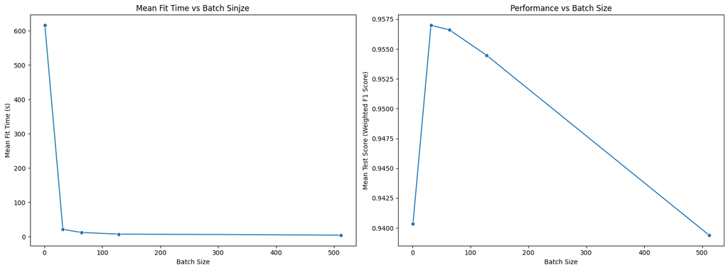

```python
# Create a new figure with two subplots side by side
fig, axes = plt.subplots(1, 2, figsize=(16, 6))

# Plot mean fit time vs batch size
sns.lineplot(data=pd.DataFrame({
    'param_batch_size': batch_sizes,
    'mean_fit_time': fit_times
}), x='param_batch_size', y='mean_fit_time', marker='o', ax=axes[0])
axes[0].set_xlabel('Batch Size')
axes[0].set_ylabel('Mean Fit Time (s)')
axes[0].set_title('Mean Fit Time vs Batch Sinjze')

# Plot performance vs batch size (using mean test score)
sns.lineplot(data=pd.DataFrame({
    'param_batch_size': batch_sizes,
    'mean_test_score': scores
}), x='param_batch_size', y='mean_test_score', marker='o', ax=axes[1])
axes[1].set_xlabel('Batch Size')
axes[1].set_ylabel('Mean Test Score (Weighted F1 Score)')
axes[1].set_title('Performance vs Batch Size')

plt.tight_layout()
plt.savefig(f'{img_dir}batch_size_vs_performance.png')
plt.show()
```